# Processing speed

# 1 Description of DataSchema variable

- Short name: `cog_proc_c`
- Variable label: `Cognition - processing speed - Continuous. Test which assesses processing speed`
- Domain: `Health status and functional limitations`
- Value type: `Continuous`
- Category missings:

| **Code** | **Category Label** |
| --- | --- |
| 991 | CAPI/interviewer error |
| 992 | Impute |
| 993 | Disable to measure |
| 994 | Not attempt/not done |
| 995 | Does not answer |
| 996 | Not applicable |
| 997 | Refuse |
| 998 | Do not know |
| 999 | Missing |

- Short name: `cog_proc`
- Variable label: `Cognition - processing speed. Test which assesses processing speed. Discrete variable: value 0 = <=25%; value 1 = >25%.`
- Domain: `Health status and functional limitations`
- Value type: `Categorical`
- Category coding:

| **Code** | **Category Label** |
| --- | --- |
| 0 | <=25% |
| 1 | >25% |

- Category missings:

| **Code** | **Category Label** |
| --- | --- |
| 991 | CAPI/interviewer error |
| 992 | Impute |
| 993 | Disable to measure |
| 994 | Not attempt/not done |
| 995 | Does not answer |
| 996 | Not applicable |
| 997 | Refuse |
| 998 | Do not know |
| 999 | Missing |

# 2 Data process

## 2.1 England

### 2.1.1 Wave 1

#### 2.1.1.1 Study-specific variable description

The study-specific variables elected to be harmonised is:

- Name: `ncorrec`
- Label: `Letter cancellation task: number correct`
- Categories:
  - `Continuous Variable 0-65`
- Missings
- `-1 = Not applicable`

Cognition - processing speed

| Sample size | Missing values |
| --- | --- |
| 12099 | 789 |

Values

|  | No-missings | -1 | NA |
| --- | --- | --- | --- |
| Frequency | 11310.00 | 789.00 | 0 |
| Percentage | 93.48 | 6.52 | 0 |

Summary

| Min. | 1st Qu. | Median | Mean | 3rd Qu. | Max. |
| --- | --- | --- | --- | --- | --- |
| 0 | 15 | 19 | 18.74 | 22 | 63 |

[figure not shown]

#### 2.1.1.2 Harmonisation algorithm

To compute the harmonize variable `cog_proc_c` from the study-specific variable the missing values have to be recoded as follows:

- `-1 Not applicable into 996`
- `NA into 999`

To compute the harmonized variable `cog_proc` from `cog_proc_c` it has to be recoded as follows:

- `cog_proc_c <=25% into 0`
- `cog_proc_c >25% into 1`

**R script:**

```r
# cog_proc_c
ELSA_ds_w1 <- tibble(id = ELSA_w1_cog_proc$id)
ELSA_ds_w1$cog_proc_c <- car::recode(ELSA_w1_cog_proc$ncorrec, "-1=996; NA=999")
ELSA_ds_w1$cog_proc_c <- labelled(ELSA_ds_w1$cog_proc_c, labels = c(Missing = 999,
    `Do not know` = 998, Refuse = 997, `Not applicable` = 996, `Does not answer` = 995,
    `Not attempt not done` = 994, `Disable to measure` = 993, Impute = 992,
    `CAPI interviewer error` = 991))

# cog_verb
Q <- quantile(car::recode(ELSA_ds_w1$cog_proc_c, "999=NA; 996=NA"), probs = 1/4,
    na.rm = TRUE, names = FALSE)

ELSA_ds_w1$cog_proc <- car::recode(ELSA_ds_w1[[2]], "0:Q=0; (Q+1):65=1")
ELSA_ds_w1$cog_proc <- labelled(ELSA_ds_w1[[3]], labels = c(`<=25%` = 0, `>25%` = 1,
    Missing = 999, `Do not know` = 998, Refuse = 997, `Not applicable` = 996,
    `Does not answer` = 995, `Not attempt not done` = 994, `Disable to measure` = 993,
    Impute = 992, `CAPI interviewer error` = 991))
```

#### 2.1.1.3 Statistical description of the new harmonised variable

Cognition - processing speed

| Sample size | Missing values |
| --- | --- |
| 12099 | 789 |

Values

|  | No-missings | 991 | 992 | 993 | 994 | 995 | 996 | 997 | 998 | 999 | NA |
| --- | --- | --- | --- | --- | --- | --- | --- | --- | --- | --- | --- |
| Frequency | 11310.00 | 0 | 0 | 0 | 0 | 0 | 789.00 | 0 | 0 | 0 | 0 |
| Percentage | 93.48 | 0 | 0 | 0 | 0 | 0 | 6.52 | 0 | 0 | 0 | 0 |

Summary

| Min. | 1st Qu. | Median | Mean | 3rd Qu. | Max. |
| --- | --- | --- | --- | --- | --- |
| 0 | 15 | 19 | 18.74 | 22 | 63 |

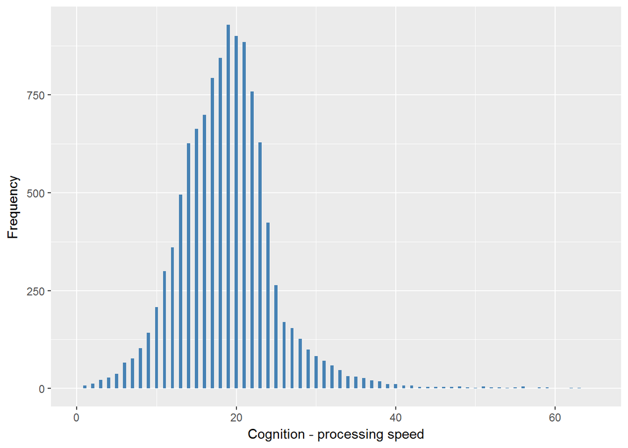

Cognition - processing speed

| Sample size | Missing values |
| --- | --- |
| 12099 | 789 |

Category

|  | 0 | 1 |
| --- | --- | --- |
| Frequency | 3161.00 | 8149.00 |
| Percentage | 26.13 | 67.35 |

Type of missing

|  | 991 | 992 | 993 | 994 | 995 | 996 | 997 | 998 | 999 | NA |
| --- | --- | --- | --- | --- | --- | --- | --- | --- | --- | --- |
| Frequency | 0 | 0 | 0 | 0 | 0 | 789.00 | 0 | 0 | 0 | 0 |
| Percentage | 0 | 0 | 0 | 0 | 0 | 6.52 | 0 | 0 | 0 | 0 |

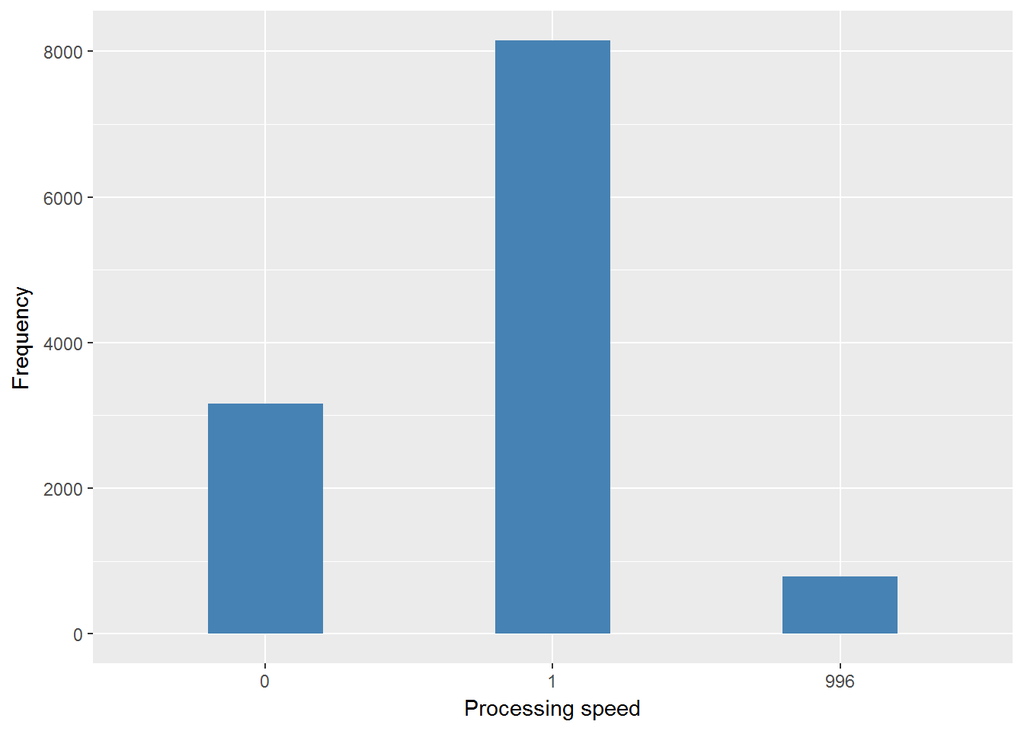

#### 2.1.1.4 Validation

Continuous vs Dichotomous

|  | 0:15->0 | 16:65->1 | -1->996 |
| --- | --- | --- | --- |
| Continous | 3161 | 8149 | 789 |
| Dicotomic | 3161 | 8149 | 789 |

### 2.1.2 Wave 2

#### 2.1.2.1 Study-specific variable description

The study-specific variables elected to be harmonised is:

- Name: `nncorre`
- Label: `Letter cancellation task: number correct`
- Categories:
  - `Continuous Variable 0-65`
- Missings
- `-1 = Not applicable`

Cognition - processing speed

| Sample size | Missing values |
| --- | --- |
| 9432 | 470 |

Values

|  | No-missings | -1 | NA |
| --- | --- | --- | --- |
| Frequency | 8962.00 | 470.00 | 0 |
| Percentage | 95.02 | 4.98 | 0 |

Summary

| Min. | 1st Qu. | Median | Mean | 3rd Qu. | Max. |
| --- | --- | --- | --- | --- | --- |
| 0 | 15 | 18 | 18.45 | 22 | 64 |

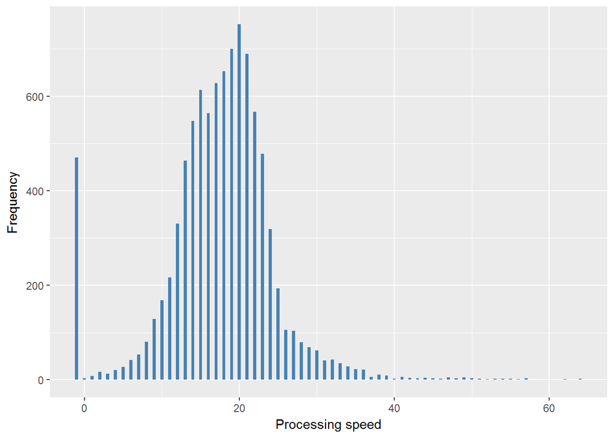

#### 2.1.2.2 Harmonisation algorithm

To compute the harmonize variable `cog_proc_c` from the study-specific variable the missing values have to be recoded as follows:

- `-1 Not applicable into 996`
- `NA into 999`

To compute the harmonized variable `cog_proc` from `cog_proc_c` it has to be recoded as follows:

- `cog_proc_c <=25% into 0`
- `cog_proc_c >25% into 1`

**R script:**

```r
# cog_proc_c
ELSA_ds_w2 <- tibble(id = ELSA_w2_cog_proc$id)
ELSA_ds_w2$cog_proc_c <- car::recode(ELSA_w2_cog_proc$nncorre, "-1=996; NA=999")
ELSA_ds_w2$cog_proc_c <- labelled(ELSA_ds_w2$cog_proc_c, labels = c(Missing = 999,
    `Do not know` = 998, Refuse = 997, `Not applicable` = 996, `Does not answer` = 995,
    `Not attempt not done` = 994, `Disable to measure` = 993, Impute = 992,
    `CAPI interviewer error` = 991))

# cog_verb
Q <- quantile(car::recode(ELSA_ds_w2$cog_proc_c, "999=NA; 996=NA"), probs = 1/4,
    na.rm = TRUE, names = FALSE)

ELSA_ds_w2$cog_proc <- car::recode(ELSA_ds_w2[[2]], "0:Q=0; (Q+1):65=1")
ELSA_ds_w2$cog_proc <- labelled(ELSA_ds_w2[[3]], labels = c(`<=25%` = 0, `>25%` = 1,
    Missing = 999, `Do not know` = 998, Refuse = 997, `Not applicable` = 996,
    `Does not answer` = 995, `Not attempt not done` = 994, `Disable to measure` = 993,
    Impute = 992, `CAPI interviewer error` = 991))
```

#### 2.1.2.3 Statistical description of the new harmonised variable

Cognition - processing speed

| Sample size | Missing values |
| --- | --- |
| 9432 | 470 |

Values

|  | No-missings | 991 | 992 | 993 | 994 | 995 | 996 | 997 | 998 | 999 | NA |
| --- | --- | --- | --- | --- | --- | --- | --- | --- | --- | --- | --- |
| Frequency | 8962.00 | 0 | 0 | 0 | 0 | 0 | 470.00 | 0 | 0 | 0 | 0 |
| Percentage | 95.02 | 0 | 0 | 0 | 0 | 0 | 4.98 | 0 | 0 | 0 | 0 |

Summary

| Min. | 1st Qu. | Median | Mean | 3rd Qu. | Max. |
| --- | --- | --- | --- | --- | --- |
| 0 | 15 | 18 | 18.45 | 22 | 64 |

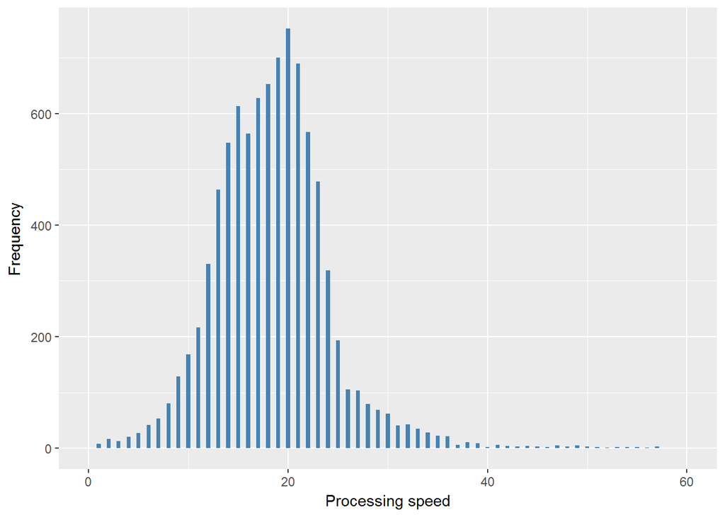

Cognition - processing speed

| Sample size | Missing values |
| --- | --- |
| 9432 | 470 |

Category

|  | 0 | 1 |
| --- | --- | --- |
| Frequency | 2729.00 | 6233.00 |
| Percentage | 28.93 | 66.08 |

Type of missing

|  | 991 | 992 | 993 | 994 | 995 | 996 | 997 | 998 | 999 | NA |
| --- | --- | --- | --- | --- | --- | --- | --- | --- | --- | --- |
| Frequency | 0 | 0 | 0 | 0 | 0 | 470.00 | 0 | 0 | 0 | 0 |
| Percentage | 0 | 0 | 0 | 0 | 0 | 4.98 | 0 | 0 | 0 | 0 |

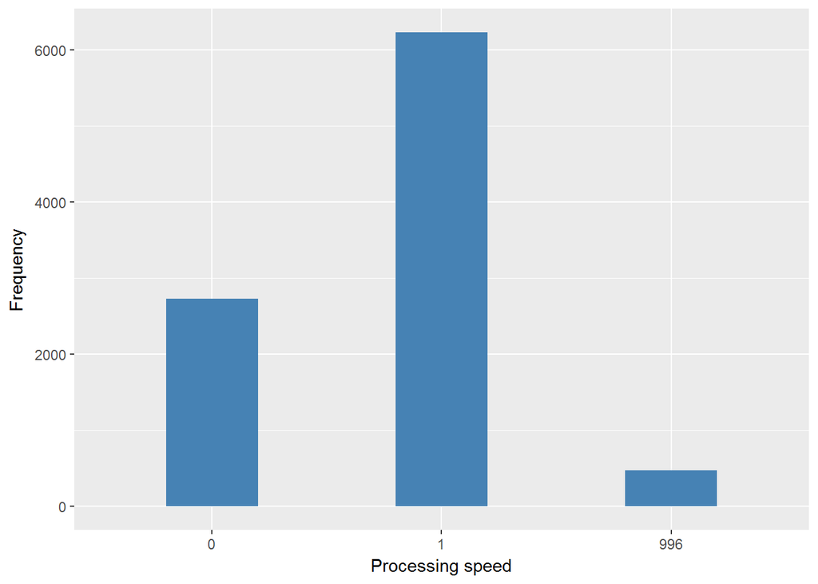

#### 2.1.2.4 Validation

Continuous vs Dichotomous

|  | 0:15->0 | 16:65->1 | -1->996 |
| --- | --- | --- | --- |
| Continous | 2729 | 6233 | 470 |
| Dicotomic | 2729 | 6233 | 470 |

### 2.1.3 Wave 3

#### 2.1.3.1 Study-specific variable description

The study-specific variables elected to be harmonised is:

- Name: `ncorrect`
- Label: `Number of words recalled immediately`
- Categories:
  - `Continuous Variable 0-65`
- Missings
- `-2 = Letter cancellation tasks done but booklet not received`
- `-1 = Not applicable`

Cognition - processing speed

| Sample size | Missing values |
| --- | --- |
| 9771 | 755 |

Values

|  | No-missings | -1 | -2 | NA |
| --- | --- | --- | --- | --- |
| Frequency | 9016.00 | 599.00 | 156.0 | 0 |
| Percentage | 92.27 | 6.13 | 1.6 | 0 |

Summary

| Min. | 1st Qu. | Median | Mean | 3rd Qu. | Max. |
| --- | --- | --- | --- | --- | --- |
| 0 | 15 | 19 | 18.98 | 22 | 64 |

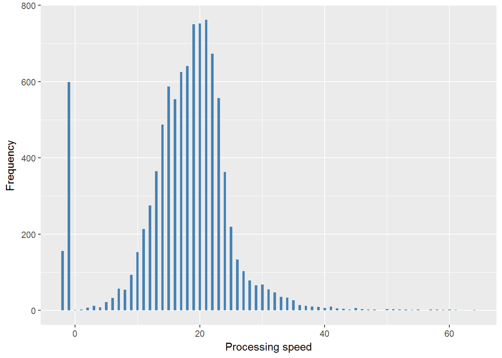

#### 2.1.3.2 Harmonisation algorithm

To compute the harmonize variable `cog_proc_c` from the study-specific variable the missing values have to be recoded as follows:

- `-1 Not applicable into 996`
- `-2 Letter cancellation tasks done but booklet not received into 996`
- `NA into 999`

To compute the harmonized variable `cog_proc` from `cog_proc_c` it has to be recoded as follows:

- `cog_proc_c <=25% into 0`
- `cog_proc_c >25% into 1`

**R script:**

```r
# cog_proc_c
ELSA_ds_w3 <- tibble(id = ELSA_w3_cog_proc$id)
ELSA_ds_w3$cog_proc_c <- car::recode(ELSA_w3_cog_proc$ncorrect, "-1=996; -2=996; NA=999")
ELSA_ds_w3$cog_proc_c <- labelled(ELSA_ds_w3$cog_proc_c, labels = c(Missing = 999,
    `Do not know` = 998, Refuse = 997, `Not applicable` = 996, `Does not answer` = 995,
    `Not attempt not done` = 994, `Disable to measure` = 993, Impute = 992,
    `CAPI interviewer error` = 991))

# cog_verb
Q <- quantile(car::recode(ELSA_ds_w3$cog_proc_c, "999=NA; 996=NA"), probs = 1/4,
    na.rm = TRUE, names = FALSE)

ELSA_ds_w3$cog_proc <- car::recode(ELSA_ds_w3[[2]], "0:Q=0; (Q+1):65=1")
ELSA_ds_w3$cog_proc <- labelled(ELSA_ds_w3[[3]], labels = c(`<=25%` = 0, `>25%` = 1,
    Missing = 999, `Do not know` = 998, Refuse = 997, `Not applicable` = 996,
    `Does not answer` = 995, `Not attempt not done` = 994, `Disable to measure` = 993,
    Impute = 992, `CAPI interviewer error` = 991))
```

#### 2.1.3.3 Statistical description of the new harmonised variable

Cognition - processing speed

| Sample size | Missing values |
| --- | --- |
| 9771 | 755 |

Values

|  | No-missings | 991 | 992 | 993 | 994 | 995 | 996 | 997 | 998 | 999 | NA |
| --- | --- | --- | --- | --- | --- | --- | --- | --- | --- | --- | --- |
| Frequency | 9016.00 | 0 | 0 | 0 | 0 | 0 | 755.00 | 0 | 0 | 0 | 0 |
| Percentage | 92.27 | 0 | 0 | 0 | 0 | 0 | 7.73 | 0 | 0 | 0 | 0 |

Summary

| Min. | 1st Qu. | Median | Mean | 3rd Qu. | Max. |
| --- | --- | --- | --- | --- | --- |
| 0 | 15 | 19 | 18.98 | 22 | 64 |

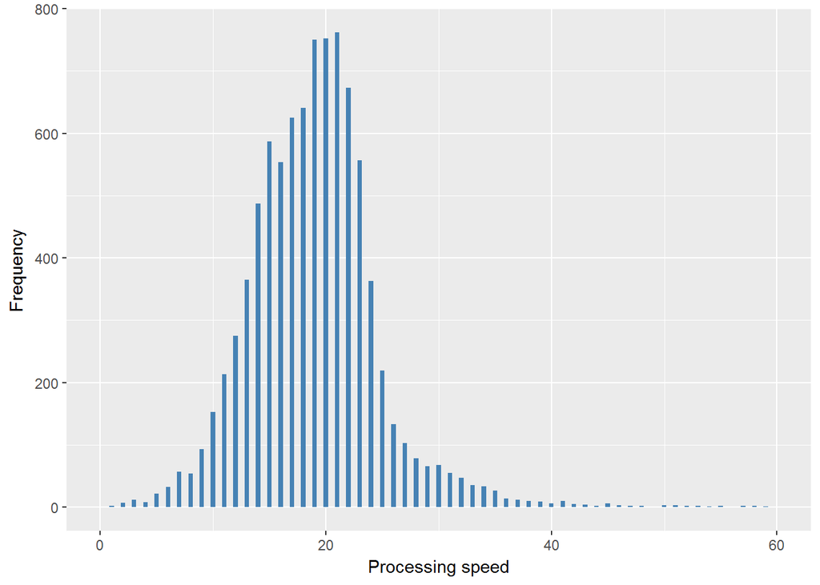

Cognition - processing speed

| Sample size | Missing values |
| --- | --- |
| 9771 | 755 |

Category

|  | 0 | 1 |
| --- | --- | --- |
| Frequency | 2368.00 | 6648.00 |
| Percentage | 24.23 | 68.04 |

Type of missing

|  | 991 | 992 | 993 | 994 | 995 | 996 | 997 | 998 | 999 | NA |
| --- | --- | --- | --- | --- | --- | --- | --- | --- | --- | --- |
| Frequency | 0 | 0 | 0 | 0 | 0 | 755.00 | 0 | 0 | 0 | 0 |
| Percentage | 0 | 0 | 0 | 0 | 0 | 7.73 | 0 | 0 | 0 | 0 |

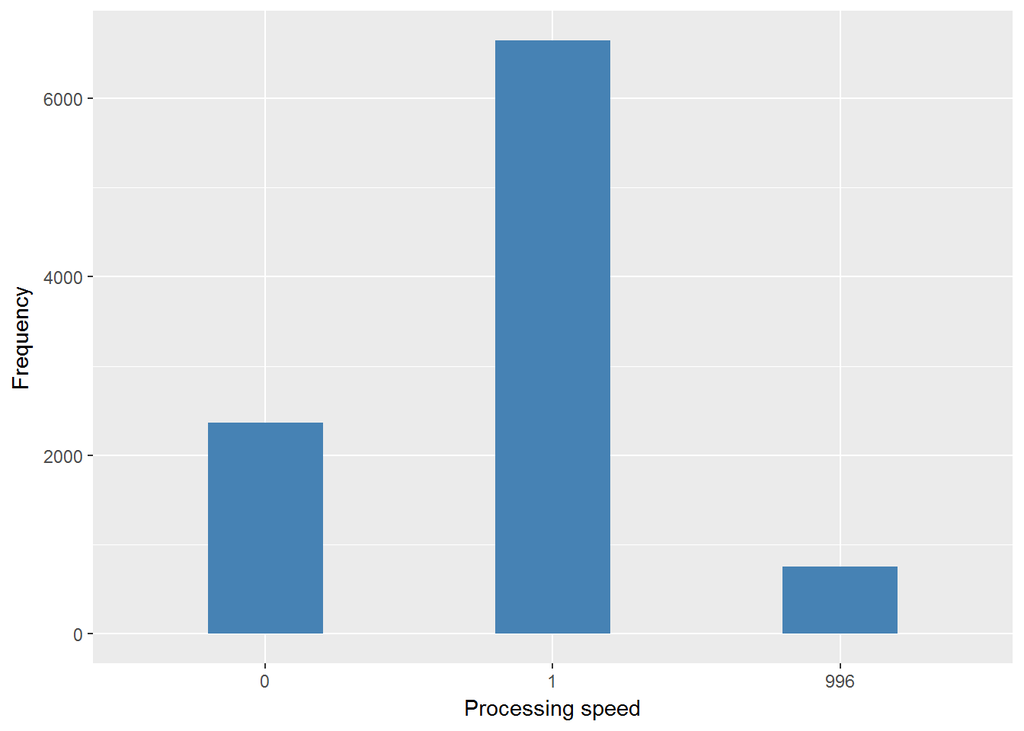

#### 2.1.3.4 Validation

Continuous vs Dichotomous

|  | 0:15->0 | 16:65->1 | -1->996 |
| --- | --- | --- | --- |
| Continous | 2368 | 6648 | 755 |
| Dicotomic | 2368 | 6648 | 755 |

### 2.1.4 Wave 4

#### 2.1.4.1 Study-specific variable description

The study-specific variables elected to be harmonised is:

- Name: `ncorrect`
- Label: `Number of words recalled immediately`
- Categories:
  - `Continuous Variable 0-65`
- Missings
- `-1 = Not applicable`

Cognition - processing speed

| Sample size | Missing values |
| --- | --- |
| 11050 | 1597 |

Values

|  | No-missings | -1 | NA |
| --- | --- | --- | --- |
| Frequency | 9453.00 | 1597.00 | 0 |
| Percentage | 85.55 | 14.45 | 0 |

Summary

| Min. | 1st Qu. | Median | Mean | 3rd Qu. | Max. |
| --- | --- | --- | --- | --- | --- |
| 0 | 16 | 19 | 19.13 | 22 | 62 |

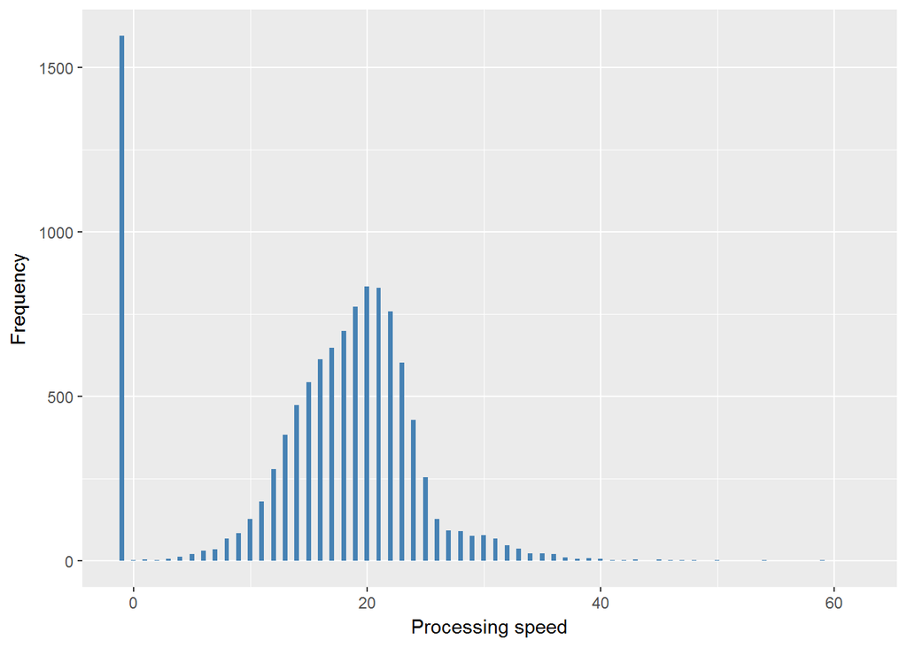

#### 2.1.4.2 Harmonisation algorithm

To compute the harmonize variable `cog_proc_c` from the study-specific variable the missing values have to be recoded as follows:

- `-1 Not applicable into 996`
- `NA into 999`

To compute the harmonized variable `cog_proc` from `cog_proc_c` it has to be recoded as follows:

- `cog_proc_c <=25% into 0`
- `cog_proc_c >25% into 1`

**R script:**

```r
# cog_proc_c
ELSA_ds_w4 <- tibble(id = ELSA_w4_cog_proc$id)
ELSA_ds_w4$cog_proc_c <- car::recode(ELSA_w4_cog_proc$ncorrect, "-1=996; NA=999")
ELSA_ds_w4$cog_proc_c <- labelled(ELSA_ds_w4$cog_proc_c, labels = c(Missing = 999,
    `Do not know` = 998, Refuse = 997, `Not applicable` = 996, `Does not answer` = 995,
    `Not attempt not done` = 994, `Disable to measure` = 993, Impute = 992,
    `CAPI interviewer error` = 991))

# cog_verb
Q <- quantile(car::recode(ELSA_ds_w4$cog_proc_c, "999=NA; 996=NA"), probs = 1/4,
    na.rm = TRUE, names = FALSE)

ELSA_ds_w4$cog_proc <- car::recode(ELSA_ds_w4[[2]], "0:Q=0; (Q+1):65=1")
ELSA_ds_w4$cog_proc <- labelled(ELSA_ds_w4[[3]], labels = c(`<=25%` = 0, `>25%` = 1,
    Missing = 999, `Do not know` = 998, Refuse = 997, `Not applicable` = 996,
    `Does not answer` = 995, `Not attempt not done` = 994, `Disable to measure` = 993,
    Impute = 992, `CAPI interviewer error` = 991))
```

#### 2.1.4.3 Statistical description of the new harmonised variable

Cognition - processing speed

| Sample size | Missing values |
| --- | --- |
| 11050 | 1597 |

Values

|  | No-missings | 991 | 992 | 993 | 994 | 995 | 996 | 997 | 998 | 999 | NA |
| --- | --- | --- | --- | --- | --- | --- | --- | --- | --- | --- | --- |
| Frequency | 9453.00 | 0 | 0 | 0 | 0 | 0 | 1597.00 | 0 | 0 | 0 | 0 |
| Percentage | 85.55 | 0 | 0 | 0 | 0 | 0 | 14.45 | 0 | 0 | 0 | 0 |

Summary

| Min. | 1st Qu. | Median | Mean | 3rd Qu. | Max. |
| --- | --- | --- | --- | --- | --- |
| 0 | 16 | 19 | 19.13 | 22 | 62 |

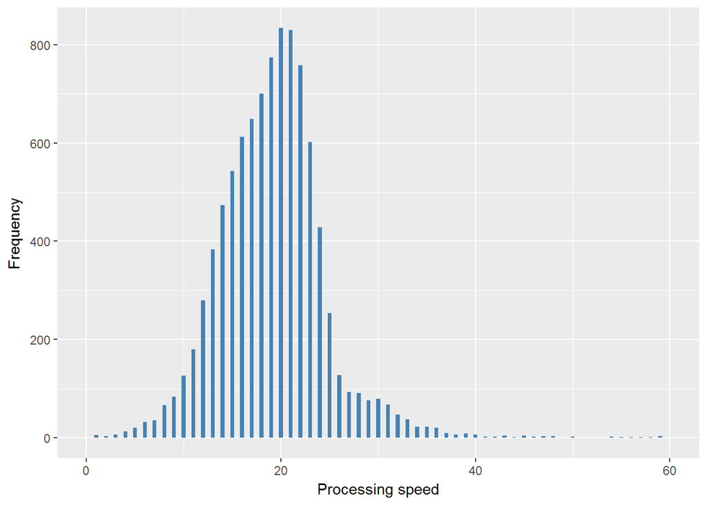

Cognition - processing speed

| Sample size | Missing values |
| --- | --- |
| 11050 | 1597 |

Category

|  | 0 | 1 |
| --- | --- | --- |
| Frequency | 2869.00 | 6584.00 |
| Percentage | 25.96 | 59.58 |

Type of missing

|  | 991 | 992 | 993 | 994 | 995 | 996 | 997 | 998 | 999 | NA |
| --- | --- | --- | --- | --- | --- | --- | --- | --- | --- | --- |
| Frequency | 0 | 0 | 0 | 0 | 0 | 1597.00 | 0 | 0 | 0 | 0 |
| Percentage | 0 | 0 | 0 | 0 | 0 | 14.45 | 0 | 0 | 0 | 0 |

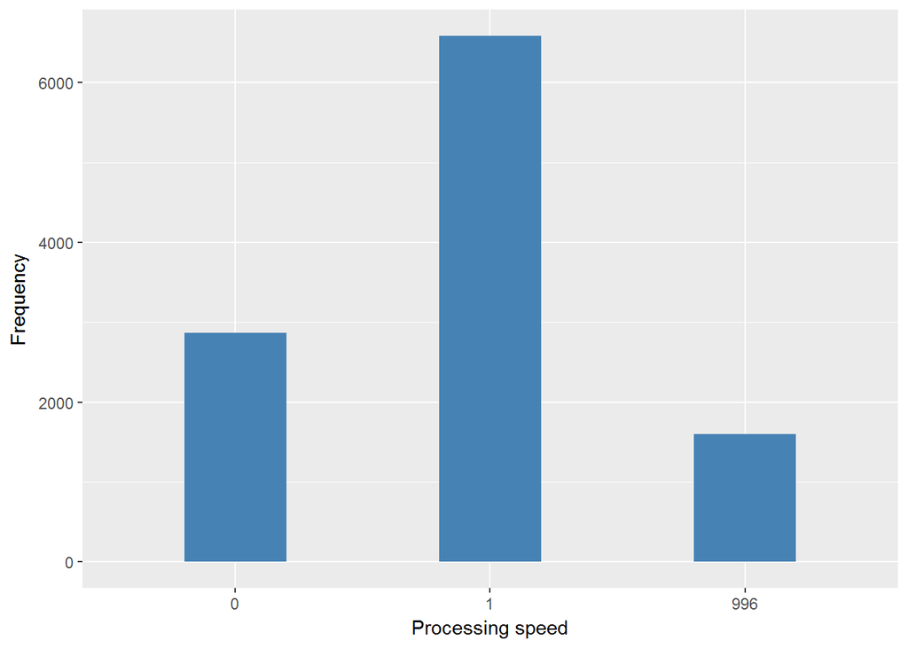

#### 2.1.4.4 Validation

Continuous vs Dichotomous

|  | 0:16->0 | 17:65->1 | -1->996 |
| --- | --- | --- | --- |
| Continous | 2869 | 6584 | 1597 |
| Dicotomic | 2869 | 6584 | 1597 |

### 2.1.5 Wave 5

#### 2.1.5.1 Study-specific variable description

The study-specific variables elected to be harmonised is:

- Name: `Ncorrect`
- Label: `Number of words recalled immediately`
- Categories:
  - `Continuous Variable 0-65`
- Missings
- `-3 = Interview/data error`
- `-1 = Not applicable`

Cognition - processing speed

| Sample size | Missing values |
| --- | --- |
| 0 | 0 |

Values

|  | No-missings | -1 | NA |
| --- | --- | --- | --- |
| Frequency | 0 | 0 | 0 |
| Percentage | NaN | NaN | NaN |

Summary

| Length | Class | Mode |
| --- | --- | --- |
| 0 | NULL | NULL |

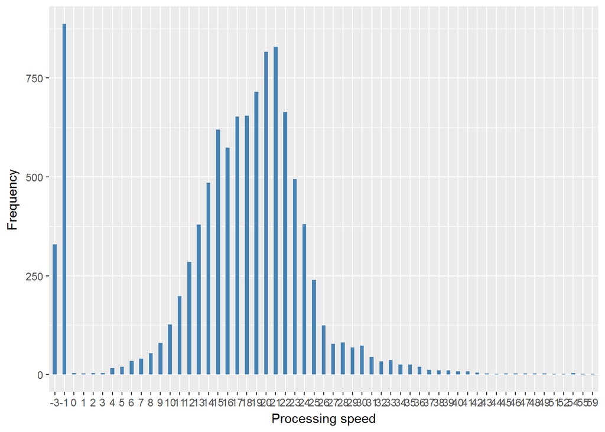

#### 2.1.5.2 Harmonisation algorithm

To compute the harmonize variable `cog_proc_c` from the study-specific variable the missing values have to be recoded as follows:

- `-1 Not applicable into 996`
- `-3 Interview/data error into 991`
- `NA into 999`

To compute the harmonized variable `cog_proc` from `cog_proc_c` it has to be recoded as follows:

- `cog_proc_c <=25% into 0`
- `cog_proc_c >25% into 1`

**R script:**

```r
# cog_proc_c
ELSA_ds_w5 <- tibble(id = ELSA_w5_cog_proc$id)
ELSA_ds_w5$cog_proc_c <- car::recode(ELSA_w5_cog_proc$NCorrect, "-1=996; -3=991; NA=999")
ELSA_ds_w5$cog_proc_c <- labelled(ELSA_ds_w5$cog_proc_c, labels = c(Missing = 999,
    `Do not know` = 998, Refuse = 997, `Not applicable` = 996, `Does not answer` = 995,
    `Not attempt not done` = 994, `Disable to measure` = 993, Impute = 992,
    `CAPI interviewer error` = 991))

# cog_verb
Q <- quantile(car::recode(ELSA_ds_w5$cog_proc_c, "999=NA; 996=NA; 991=NA"),
    probs = 1/4, na.rm = TRUE, names = FALSE)

ELSA_ds_w5$cog_proc <- car::recode(ELSA_ds_w5[[2]], "0:Q=0; (Q+1):65=1")
ELSA_ds_w5$cog_proc <- labelled(ELSA_ds_w5[[3]], labels = c(`<=25%` = 0, `>25%` = 1,
    Missing = 999, `Do not know` = 998, Refuse = 997, `Not applicable` = 996,
    `Does not answer` = 995, `Not attempt not done` = 994, `Disable to measure` = 993,
    Impute = 992, `CAPI interviewer error` = 991))
```

#### 2.1.5.3 Statistical description of the new harmonised variable

Cognition - processing speed

| Sample size | Missing values |
| --- | --- |
| 10274 | 1216 |

Values

|  | No-missings | 991 | 992 | 993 | 994 | 995 | 996 | 997 | 998 | 999 | NA |
| --- | --- | --- | --- | --- | --- | --- | --- | --- | --- | --- | --- |
| Frequency | 9058.00 | 329.0 | 0 | 0 | 0 | 0 | 887.00 | 0 | 0 | 0 | 0 |
| Percentage | 88.16 | 3.2 | 0 | 0 | 0 | 0 | 8.63 | 0 | 0 | 0 | 0 |

Summary

| Min. | 1st Qu. | Median | Mean | 3rd Qu. | Max. |
| --- | --- | --- | --- | --- | --- |
| 0 | 15 | 19 | 18.92 | 22 | 59 |

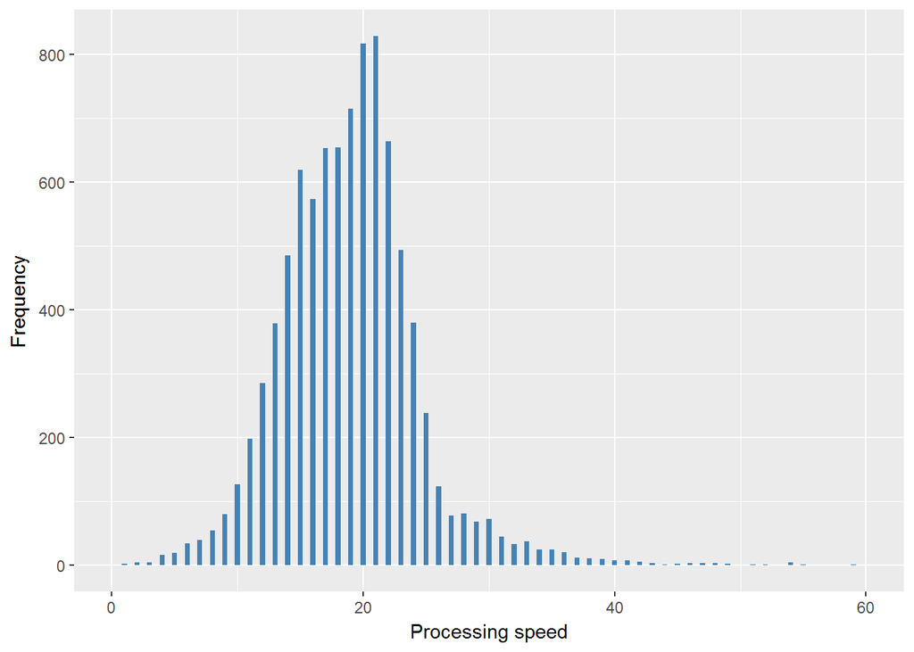

Cognition - processing speed

| Sample size | Missing values |
| --- | --- |
| 10274 | 1216 |

Category

|  | 0 | 1 |
| --- | --- | --- |
| Frequency | 2350.00 | 6708.00 |
| Percentage | 22.87 | 65.29 |

Type of missing

|  | 991 | 992 | 993 | 994 | 995 | 996 | 997 | 998 | 999 | NA |
| --- | --- | --- | --- | --- | --- | --- | --- | --- | --- | --- |
| Frequency | 329.0 | 0 | 0 | 0 | 0 | 887.00 | 0 | 0 | 0 | 0 |
| Percentage | 3.2 | 0 | 0 | 0 | 0 | 8.63 | 0 | 0 | 0 | 0 |

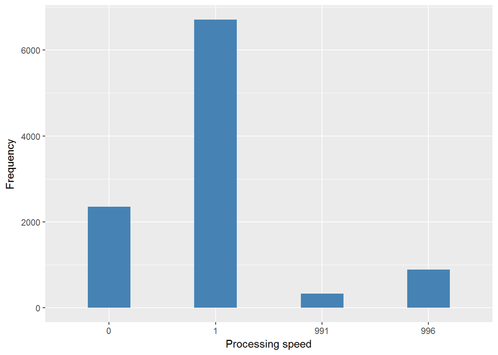

#### 2.1.5.4 Validation

Continuous vs Dichotomous

|  | 0:15->0 | 16:65->1 | -3->991 | -1->996 |
| --- | --- | --- | --- | --- |
| Continous | 2350 | 6708 | 329 | 887 |
| Dicotomic | 2350 | 6708 | 329 | 887 |

### 2.1.6 Wave 6

Not collected at wave 6.

### 2.1.7 Wave 7

Not collected at wave 7.

# 3 Quality estimation

No comments